*KU, Shin wooyoung*

# Introduction

The examples were obtained by scanning some actual hand-drawn digits, and then generating additional images by random horizional shifts. Five different networks were fit to the data, and showing detials about these.

- $Net-1$: No hidden layer, equivalent to multinomial logistic regression.
- $Net-2$: One hidden layer, 12 hidden units fully connected.
- $Net-3$: Two hidden layers locally connected.
- $Net-4$: Two hidden layers, locally connected with weight sharing.
- $Net-5$: Two hidden layers, locally connected, two levels of weight sharing

# Explore train, test data

```python
%reset -f
```

```python
from __future__ import print_function
import warnings
warnings.filterwarnings(action='ignore')
import pandas as pd
import numpy as np
import math
import matplotlib
import matplotlib.pyplot as plt
import os
import time
os.environ["CUDA_VISIBLE_DEVICES"] = ""
```

```python
import chardet

def find_encoding(fname):
    r_file = open(fname, 'rb').read()
    result = chardet.detect(r_file)
    charenc = result['encoding']
    return charenc

path = r"C:\Users\shin\Desktop\project\private\neural_network"
train= os.path.join(path, "train.csv")
test = os.path.join(path, "test.csv")

my_encoding1 = find_encoding(train)
my_encoding2 = find_encoding(test)

train= pd.read_csv(train,encoding = my_encoding1, header = None)
test = pd.read_csv(test, encoding = my_encoding2, header = None)
```

```python
display(f"Training set dimension is {train.shape}", train.head())
train_t = np.array(train.iloc[:,0])
train_X = np.array(train.drop(columns = [0]))
```

```
'Training set dimension is (7291, 257)'
```

|  | 0 | 1 | 2 | 3 | 4 | 5 | 6 | 7 | 8 | 9 | ... | 247 | 248 | 249 | 250 | 251 | 252 | 253 | 254 | 255 | 256 |
| --- | --- | --- | --- | --- | --- | --- | --- | --- | --- | --- | --- | --- | --- | --- | --- | --- | --- | --- | --- | --- | --- |
| 0 | 6 | -1.0 | -1.0 | -1.0 | -1.000 | -1.000 | -1.000 | -1.000 | -0.631 | 0.862 | ... | 0.304 | 0.823 | 1.000 | 0.482 | -0.474 | -0.991 | -1.000 | -1.000 | -1.000 | -1.0 |
| 1 | 5 | -1.0 | -1.0 | -1.0 | -0.813 | -0.671 | -0.809 | -0.887 | -0.671 | -0.853 | ... | -0.671 | -0.671 | -0.033 | 0.761 | 0.762 | 0.126 | -0.095 | -0.671 | -0.828 | -1.0 |
| 2 | 4 | -1.0 | -1.0 | -1.0 | -1.000 | -1.000 | -1.000 | -1.000 | -1.000 | -1.000 | ... | -1.000 | -1.000 | -1.000 | -0.109 | 1.000 | -0.179 | -1.000 | -1.000 | -1.000 | -1.0 |
| 3 | 7 | -1.0 | -1.0 | -1.0 | -1.000 | -1.000 | -0.273 | 0.684 | 0.960 | 0.450 | ... | -0.318 | 1.000 | 0.536 | -0.987 | -1.000 | -1.000 | -1.000 | -1.000 | -1.000 | -1.0 |
| 4 | 3 | -1.0 | -1.0 | -1.0 | -1.000 | -1.000 | -0.928 | -0.204 | 0.751 | 0.466 | ... | 0.466 | 0.639 | 1.000 | 1.000 | 0.791 | 0.439 | -0.199 | -0.883 | -1.000 | -1.0 |

5 rows × 257 columns

```python
display(f"Test set dimension is {test.shape}", test.head())
test_t = np.array(test.iloc[:,0])
test_X = np.array(test.drop(columns = [0]))
```

```
'Test set dimension is (2007, 257)'
```

|  | 0 | 1 | 2 | 3 | 4 | 5 | 6 | 7 | 8 | 9 | ... | 247 | 248 | 249 | 250 | 251 | 252 | 253 | 254 | 255 | 256 |
| --- | --- | --- | --- | --- | --- | --- | --- | --- | --- | --- | --- | --- | --- | --- | --- | --- | --- | --- | --- | --- | --- |
| 0 | 9 | -1.0 | -1.0 | -1.0 | -1.000 | -1.0 | -0.948 | -0.561 | 0.148 | 0.384 | ... | -1.000 | -0.908 | 0.430 | 0.622 | -0.973 | -1.000 | -1.0 | -1.0 | -1.0 | -1.0 |
| 1 | 6 | -1.0 | -1.0 | -1.0 | -1.000 | -1.0 | -1.000 | -1.000 | -1.000 | -1.000 | ... | -1.000 | -1.000 | -1.000 | -1.000 | -1.000 | -1.000 | -1.0 | -1.0 | -1.0 | -1.0 |
| 2 | 3 | -1.0 | -1.0 | -1.0 | -0.593 | 0.7 | 1.000 | 1.000 | 1.000 | 1.000 | ... | 1.000 | 0.717 | 0.333 | 0.162 | -0.393 | -1.000 | -1.0 | -1.0 | -1.0 | -1.0 |
| 3 | 6 | -1.0 | -1.0 | -1.0 | -1.000 | -1.0 | -1.000 | -1.000 | -1.000 | -1.000 | ... | -1.000 | -1.000 | -1.000 | -1.000 | -1.000 | -1.000 | -1.0 | -1.0 | -1.0 | -1.0 |
| 4 | 6 | -1.0 | -1.0 | -1.0 | -1.000 | -1.0 | -1.000 | -1.000 | -0.858 | -0.106 | ... | 0.901 | 0.901 | 0.901 | 0.290 | -0.369 | -0.867 | -1.0 | -1.0 | -1.0 | -1.0 |

5 rows × 257 columns

```python
from sklearn.linear_model import LogisticRegression
clf = LogisticRegression(random_state=0, solver="newton-cg",
                         multi_class='multinomial').fit(train_X, train_t)
```

I tried to fit multinomial logistic regression it simply. And that's score is below.

```python
clf.score(test_X, test_t)
```

```
0.9123069257598405
```

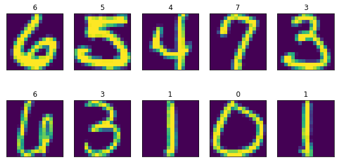

```python
import matplotlib.pyplot as plt
images = train_X[0:10,:]
labels = train_t[0:10]
fig = plt.figure(figsize = (10, 5))
for c, (image, label) in enumerate(zip(images, labels)):
    subplot = fig.add_subplot(2, 5, c + 1)
    subplot.set_xticks([])
    subplot.set_yticks([])
    subplot.set_title(label)
    subplot.imshow(image.reshape(16, 16))

train_t= np.array(pd.get_dummies(train_t))
test_t = np.array(pd.get_dummies(test_t))
```

Images shown here have been deslanted and size normalized, resulting in $16 \times 16$ grayscale images. These 256 pixel values are used as inputs to the neural network classifier, and ten output units for each of the digits $0 - 9$.

# Simulation

## Net-1

```python
import tensorflow as tf
```

```python
num_factors = 10
num_features = 256

batch_size = 1000

X = tf.placeholder(tf.float32, shape=[None, num_features])
w = tf.Variable(tf.zeros([num_features, num_factors]))
b = tf.Variable(tf.zeros([num_factors]))
f = tf.matmul(X, w) + b
p = tf.nn.softmax(f)

t = tf.placeholder(tf.float32, [None, num_factors])
loss = -tf.reduce_sum(t*tf.log(p))
train_step = tf.train.AdamOptimizer().minimize(loss)

correct_prediction = tf.equal(tf.sign(p-0.5), tf.sign(t-0.5))
#correct_prediction = tf.equal(tf.argmax(p, 1), tf.argmax(t, 1))
accuracy = tf.reduce_mean(tf.cast(correct_prediction, tf.float32))
# cast : change data type as tf.float32 becuse correct_prediction is bools type
```

```python
class Batch:

    def __init__(self, data):
        self._index_in_epoch = 0
        self._epochs_completed = 0
        self._data = data
        self._num_examples = data.shape[0]
        pass

    @property
    def data(self):
        return self._data

    def next_batch(self,batch_size,shuffle = True):
        start = self._index_in_epoch
        if start == 0 and self._epochs_completed == 0:
            idx = np.arange(0, self._num_examples)
            np.random.shuffle(idx)
            self._data = self.data[idx]

        # go to the next batch
        if start + batch_size > self._num_examples:
            self._epochs_completed += 1
            rest_num_examples = self._num_examples - start
            data_rest_part = self.data[start:self._num_examples]
            idx0 = np.arange(0, self._num_examples)
            np.random.shuffle(idx0)
            self._data = self.data[idx0]

            start = 0
            self._index_in_epoch = batch_size - rest_num_examples
            end =  self._index_in_epoch
            data_new_part =  self._data[start:end]
            return np.concatenate((data_rest_part,
                                   data_new_part),axis=0),self._epochs_completed
        else:
            self._index_in_epoch += batch_size
            end = self._index_in_epoch
            return self._data[start:end], self._epochs_completed
```

```python
np.random.seed(1)
tf.set_random_seed(1)

sess = tf.Session()
sess.run(tf.global_variables_initializer())

train_accuracy1= []
test_accuracy1 = []

i = 0
combinded_train = Batch(np.c_[train_X, train_t])
p = train_X.shape[1]

for _ in range(2001):
    i += 1
    combinded_batch, epoch = combinded_train.next_batch(batch_size)
    X_batch = combinded_batch[:,0:p]
    t_batch = combinded_batch[:,p:]
    _, loss_val = sess.run([train_step, loss],
                           feed_dict = {X: X_batch, t: t_batch})
    if i % 200 == 0 or i == 1:
        train_acc = sess.run(accuracy, feed_dict = {X: X_batch, t: t_batch})
        train_accuracy1.append(train_acc)
        test_acc = sess.run(accuracy, feed_dict = {X: test_X, t: test_t})
        test_accuracy1.append(test_acc)
        print('step:%d,loss:%f,Train:%f,Test:%f'
              %(i,loss_val,train_acc,test_acc))
```

```
step:1,loss:2302.582764,Train:0.900000,Test:0.900000
step:200,loss:296.733032,Train:0.986100,Test:0.978625
step:400,loss:228.372711,Train:0.989100,Test:0.982611
step:600,loss:173.178253,Train:0.990500,Test:0.983059
step:800,loss:128.037064,Train:0.994100,Test:0.983558
step:1000,loss:141.963074,Train:0.992400,Test:0.983856
step:1200,loss:141.791351,Train:0.993700,Test:0.983906
step:1400,loss:121.788406,Train:0.994700,Test:0.983807
step:1600,loss:120.941025,Train:0.992000,Test:0.984106
step:1800,loss:86.800728,Train:0.996000,Test:0.984155
step:2000,loss:100.591339,Train:0.996000,Test:0.983906
```

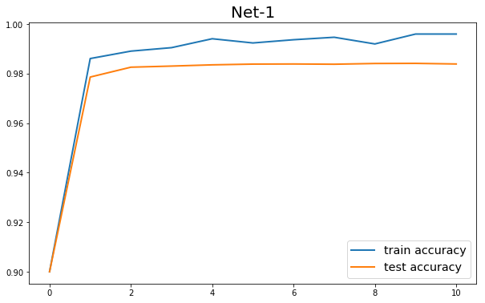

```python
fig = plt.figure(figsize = (10, 6))
subplot = fig.add_subplot(1, 1, 1)
subplot.plot(train_accuracy1,linewidth = 2, label = "train accuracy")
subplot.plot(test_accuracy1, linewidth = 2, label = "test accuracy")
subplot.legend(loc = 'lower right', fontsize = 'x-large')
subplot.set_title("Net-1", fontsize = 20)
```

$Net-1$ links $(256 + 1)\times 10 = 2570$, and $(256 + 1)\times 10 = 2570$ weights.

## Net-2

$Net-2$ is a single hidden layer network with 12 hidden units.

```python
num_factors = 10
num_features = 256
num_units1 = 12

batch_size = 1000

# first layer
X = tf.placeholder(tf.float32, shape=[None, num_features])
w1 = tf.Variable(tf.truncated_normal([num_features, num_units1]))
b1 = tf.Variable(tf.zeros([num_units1]))
hidden1 = tf.nn.tanh(tf.matmul(X, w1) + b1)

w2 = tf.Variable(tf.truncated_normal([num_units1, num_factors]))
b2 = tf.Variable(tf.zeros([num_factors]))
p = tf.nn.softmax(tf.matmul(hidden1, w2) + b2)

t = tf.placeholder(tf.float32, [None, num_factors])
loss = -tf.reduce_sum(t*tf.log(p))
train_step = tf.train.AdamOptimizer().minimize(loss)

correct_prediction = tf.equal(tf.sign(p-0.5), tf.sign(t-0.5))
#correct_prediction = tf.equal(tf.argmax(p, 1), tf.argmax(t, 1))
accuracy = tf.reduce_mean(tf.cast(correct_prediction, tf.float32))
```

```python
np.random.seed(1)
tf.set_random_seed(1)

sess = tf.Session()
sess.run(tf.global_variables_initializer())

train_accuracy2= []
test_accuracy2 = []

i = 0
combinded_train = Batch(np.c_[train_X, train_t])
p = train_X.shape[1]

for _ in range(2001):
    i += 1
    combinded_batch, epoch = combinded_train.next_batch(batch_size)
    X_batch = combinded_batch[:,0:p]
    t_batch = combinded_batch[:,p:]
    _, loss_val = sess.run([train_step, loss],
                           feed_dict = {X: X_batch, t: t_batch})
    if i % 200 == 0 or i == 1:
        train_acc = sess.run(accuracy, feed_dict = {X: X_batch, t: t_batch})
        train_accuracy2.append(train_acc)
        test_acc = sess.run(accuracy, feed_dict = {X: test_X, t: test_t})
        test_accuracy2.append(test_acc)
        print('step:%d,loss:%f,Train:%f,Test:%f'
              %(i,loss_val,train_acc,test_acc))
```

```
step:1,loss:4164.721191,Train:0.840500,Test:0.843498
step:200,loss:1688.838867,Train:0.913700,Test:0.908769
step:400,loss:1093.436523,Train:0.941000,Test:0.930144
step:600,loss:834.194641,Train:0.953700,Test:0.944395
step:800,loss:672.903809,Train:0.964400,Test:0.952965
step:1000,loss:576.246338,Train:0.969800,Test:0.959542
step:1200,loss:465.320435,Train:0.975100,Test:0.963727
step:1400,loss:425.068207,Train:0.977800,Test:0.965969
step:1600,loss:412.370056,Train:0.977500,Test:0.968361
step:1800,loss:314.549377,Train:0.983300,Test:0.969307
step:2000,loss:304.247681,Train:0.984100,Test:0.969806
```

```python
epoch
```

```
274
```

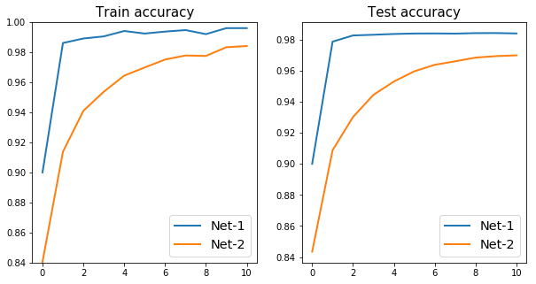

```python
fig = plt.figure(figsize = (10, 5))
ax1 = fig.add_subplot(1, 2, 1)
ax2 = fig.add_subplot(1, 2, 2)
ax1.plot(train_accuracy1, linewidth = 2, label = "Net-1")
ax1.plot(train_accuracy2, linewidth = 2, label = "Net-2")
ax1.legend(loc = 'lower right', fontsize = 'x-large')
ax1.set_title("Train accuracy", fontsize = 15)
ax1.set_ylim(0.84, 1)
ax2.plot(test_accuracy1, linewidth = 2, label = "Net-1")
ax2.plot(test_accuracy2, linewidth = 2, label = "Net-2")
ax2.legend(loc = 'lower right', fontsize = 'x-large')
ax2.set_title("Test accuracy", fontsize = 15)
```

$Net-2$ links $(256 + 1)\times 12 + (12 + 1)\times 10 = 3214$, and $(256 + 1)\times 12 + (12 + 1)\times 10 = 3214$ weights.

## Net-3

$Net-3$ uses local connectivity which means that each hidden unit is connected to only a small patch of units in the layer. In the first hidden layer(an $8 \times 8$ array), each unit takes inputs from a $3 \times 3$ filter of the input layer. In the second hidden layer, inputs are from a $5 \times 5$ filter, and again units that are one unit apart have receptive fields that are two units aparts. The weights for all other connections are set to zero. Local connectivity makes each unit responsible for extracting local features from the layer, and reduces considerably the total number of weights.

```python
num_filters1 = 1
num_factors = 10
num_features = 256

batch_size = 1000

X = tf.placeholder(tf.float32, [None, num_features])
X_image = tf.reshape(X, [-1, 16, 16, 1])
W_conv1 = tf.Variable(tf.truncated_normal([3, 3, 1, num_filters1]
                                          , stddev = 0.1))
h_conv1 = tf.nn.conv2d(X_image, W_conv1, strides = [1, 1, 1, 1]
                       , padding = "SAME")
h_conv1_cutoff = tf.nn.relu(h_conv1)
h_pool1 = tf.nn.max_pool(h_conv1_cutoff, ksize = [1, 2, 2, 1],
                         strides = [1, 2, 2, 1], padding = "SAME")

num_filters2 = 1
W_conv2 = tf.Variable(tf.truncated_normal([5, 5, num_filters1, num_filters2]
                                          , stddev = 0.1))
h_conv2 = tf.nn.conv2d(h_pool1, W_conv2, strides = [1, 1, 1, 1]
                       , padding = "SAME")
h_conv2_cutoff = tf.nn.relu(h_conv2)
h_pool2 = tf.nn.max_pool(h_conv2_cutoff, ksize = [1, 2, 2, 1],
                         strides = [1, 2, 2, 1], padding = "SAME")

h_pool2_flat = tf.reshape(h_pool2, [-1, 4*4*num_filters2])
w = tf.Variable(tf.zeros([4*4*num_filters2, num_factors]))
b = tf.Variable(tf.zeros([num_factors]))
f = tf.matmul(h_pool2_flat, w) + b
p = tf.nn.softmax(f)

t = tf.placeholder(tf.float32, [None, num_factors])
loss = -tf.reduce_sum(t*tf.log(p))
train_step = tf.train.AdamOptimizer().minimize(loss)

correct_prediction = tf.equal(tf.sign(p-0.5), tf.sign(t-0.5))
#correct_prediction = tf.equal(tf.argmax(p, 1), tf.argmax(t, 1))
accuracy = tf.reduce_mean(tf.cast(correct_prediction, tf.float32))
```

```python
np.random.seed(1)
tf.set_random_seed(1)

sess = tf.Session()
sess.run(tf.global_variables_initializer())

train_accuracy3= []
test_accuracy3 = []

i = 0
combinded_train = Batch(np.c_[train_X, train_t])
p = train_X.shape[1]

for _ in range(2001):
    i += 1
    combinded_batch, epoch = combinded_train.next_batch(batch_size)
    X_batch = combinded_batch[:,0:p]
    t_batch = combinded_batch[:,p:]
    _, loss_val = sess.run([train_step, loss],
                           feed_dict = {X: X_batch, t: t_batch})
    if i % 200 == 0 or i == 1:
        train_acc = sess.run(accuracy, feed_dict = {X: X_batch, t: t_batch})
        train_accuracy3.append(train_acc)
        test_acc = sess.run(accuracy, feed_dict = {X: test_X, t: test_t})
        test_accuracy3.append(test_acc)
        print('step:%d,loss:%f,Train:%f,Test:%f'
              %(i,loss_val,train_acc,test_acc))
```

```
step:1,loss:2302.582764,Train:0.900000,Test:0.900000
step:200,loss:1070.850952,Train:0.929300,Test:0.929297
step:400,loss:590.783630,Train:0.964100,Test:0.957897
step:600,loss:455.994873,Train:0.972400,Test:0.965770
step:800,loss:387.003967,Train:0.977000,Test:0.969706
step:1000,loss:365.799774,Train:0.977900,Test:0.970852
step:1200,loss:343.319458,Train:0.979400,Test:0.971400
step:1400,loss:334.340851,Train:0.978800,Test:0.972546
step:1600,loss:345.072845,Train:0.980500,Test:0.973343
step:1800,loss:284.544800,Train:0.982400,Test:0.973692
step:2000,loss:320.098389,Train:0.980800,Test:0.974141
```

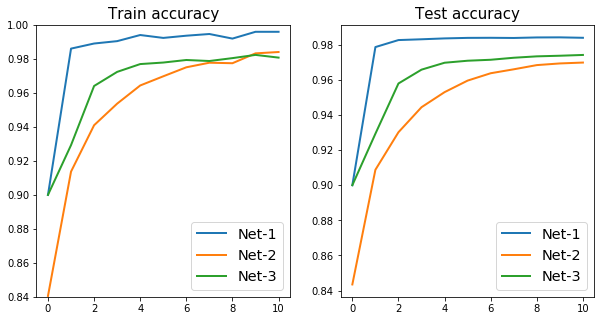

```python
ax1.plot(train_accuracy3, linewidth = 2, label = "Net-3")
ax1.legend(loc = 'lower right', fontsize = 'x-large')
ax2.plot(test_accuracy3, linewidth = 2, label = "Net-3")
ax2.legend(loc = 'lower right', fontsize = 'x-large')
fig
```

## Net-4

$Net-4$ have local connectivity with shared weights. All units in a local feature map perform the $same$ operation on different parts of the image. In the first hidden layer, each unit takes inputs from two $3 \times 3$ filters of the input layer and make two $8 \times 8$ images. Then in the second hidden layer, each unit takes inputs from a $5 \times 5$ filter of the input layer and make a $4 \times 4$ image. Finally fully connect second hidden units.

```python
num_filters1 = 2
num_factors = 10
num_features = 256

batch_size = 1000

X = tf.placeholder(tf.float32, [None, num_features])
X_image = tf.reshape(X, [-1, 16, 16, 1])
W_conv1 = tf.Variable(tf.truncated_normal([3, 3, 1, num_filters1]
                                          , stddev = 0.1))
h_conv1 = tf.nn.conv2d(X_image, W_conv1, strides = [1, 1, 1, 1]
                       , padding = "SAME")
h_conv1_cutoff = tf.nn.relu(h_conv1)
h_pool1 = tf.nn.max_pool(h_conv1_cutoff, ksize = [1, 2, 2, 1],
                         strides = [1, 2, 2, 1], padding = "SAME")

num_filters2 = 1
W_conv2 = tf.Variable(tf.truncated_normal([5, 5, num_filters1, num_filters2]
                                          , stddev = 0.1))
h_conv2 = tf.nn.conv2d(h_pool1, W_conv2, strides = [1, 1, 1, 1]
                       , padding = "SAME")
h_conv2_cutoff = tf.nn.relu(h_conv2)
h_pool2 = tf.nn.max_pool(h_conv2_cutoff, ksize = [1, 2, 2, 1],
                         strides = [1, 2, 2, 1], padding = "SAME")

h_pool2_flat = tf.reshape(h_pool2, [-1, 4*4*num_filters2])
w = tf.Variable(tf.zeros([4*4*num_filters2, num_factors]))
b = tf.Variable(tf.zeros([num_factors]))
f = tf.matmul(h_pool2_flat, w) + b
p = tf.nn.softmax(f)

t = tf.placeholder(tf.float32, [None, num_factors])
loss = -tf.reduce_sum(t*tf.log(p))
train_step = tf.train.AdamOptimizer().minimize(loss)

correct_prediction = tf.equal(tf.sign(p-0.5), tf.sign(t-0.5))
#correct_prediction = tf.equal(tf.argmax(p, 1), tf.argmax(t, 1))
accuracy = tf.reduce_mean(tf.cast(correct_prediction, tf.float32))
```

```python
np.random.seed(1)
tf.set_random_seed(1)

sess = tf.Session()
sess.run(tf.global_variables_initializer())

train_accuracy4= []
test_accuracy4 = []

i = 0
combinded_train = Batch(np.c_[train_X, train_t])
p = train_X.shape[1]

for _ in range(2001):
    i += 1
    combinded_batch, epoch = combinded_train.next_batch(batch_size)
    X_batch = combinded_batch[:,0:p]
    t_batch = combinded_batch[:,p:]
    _, loss_val = sess.run([train_step, loss],
                           feed_dict = {X: X_batch, t: t_batch})
    if i % 200 == 0 or i == 1:
        train_acc = sess.run(accuracy, feed_dict = {X: X_batch, t: t_batch})
        train_accuracy4.append(train_acc)
        test_acc = sess.run(accuracy, feed_dict = {X: test_X, t: test_t})
        test_accuracy4.append(test_acc)
        print('step:%d,loss:%f,Train:%f,Test:%f'
              %(i,loss_val,train_acc,test_acc))
```

```
step:1,loss:2302.582764,Train:0.900000,Test:0.900000
step:200,loss:811.947388,Train:0.952200,Test:0.948680
step:400,loss:487.782715,Train:0.972000,Test:0.965072
step:600,loss:422.859497,Train:0.973800,Test:0.968909
step:800,loss:361.658936,Train:0.978200,Test:0.971948
step:1000,loss:342.352631,Train:0.981100,Test:0.972745
step:1200,loss:323.405487,Train:0.983800,Test:0.973343
step:1400,loss:291.422852,Train:0.983000,Test:0.973692
step:1600,loss:299.248657,Train:0.983800,Test:0.974938
step:1800,loss:268.662109,Train:0.985700,Test:0.975336
step:2000,loss:271.892426,Train:0.983600,Test:0.975486
```

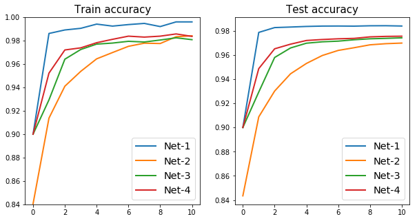

```python
ax1.plot(train_accuracy4, linewidth = 2, label = "Net-4")
ax1.legend(loc = 'lower right', fontsize = 'x-large')
ax2.plot(test_accuracy4, linewidth = 2, label = "Net-4")
ax2.legend(loc = 'lower right', fontsize = 'x-large')
fig
```

## Net-5

$Net-5$ have local connectivity with shared weights. All units in a local feature map perform the $same$ operation on different parts of the image. In the first hidden layer, each unit takes inputs from two $3 \times 3$ filters of the input layer and make two $8 \times 8$ images. Then in the second hidden layer, each unit takes inputs from four $5 \times 5$ filter of the input layer and make four $4 \times 4$ images. Finally fully connect second hidden units.

```python
num_filters1 = 2
num_factors = 10
num_features = 256

batch_size = 1000

X = tf.placeholder(tf.float32, [None, num_features])
X_image = tf.reshape(X, [-1, 16, 16, 1])
W_conv1 = tf.Variable(tf.truncated_normal([3, 3, 1, num_filters1]
                                          , stddev = 0.1))
h_conv1 = tf.nn.conv2d(X_image, W_conv1, strides = [1, 1, 1, 1]
                       , padding = "SAME")
h_conv1_cutoff = tf.nn.relu(h_conv1)
h_pool1 = tf.nn.max_pool(h_conv1_cutoff, ksize = [1, 2, 2, 1],
                         strides = [1, 2, 2, 1], padding = "SAME")

num_filters2 = 4
W_conv2 = tf.Variable(tf.truncated_normal([5, 5, num_filters1, num_filters2]
                                          , stddev = 0.1))
h_conv2 = tf.nn.conv2d(h_pool1, W_conv2, strides = [1, 1, 1, 1]
                       , padding = "SAME")
h_conv2_cutoff = tf.nn.relu(h_conv2)
h_pool2 = tf.nn.max_pool(h_conv2_cutoff, ksize = [1, 2, 2, 1],
                         strides = [1, 2, 2, 1], padding = "SAME")

h_pool2_flat = tf.reshape(h_pool2, [-1, 4*4*num_filters2])
w = tf.Variable(tf.zeros([4*4*num_filters2, num_factors]))
b = tf.Variable(tf.zeros([num_factors]))
f = tf.matmul(h_pool2_flat, w) + b
p = tf.nn.softmax(f)

t = tf.placeholder(tf.float32, [None, num_factors])
loss = -tf.reduce_sum(t*tf.log(p))
train_step = tf.train.AdamOptimizer().minimize(loss)

correct_prediction = tf.equal(tf.sign(p-0.5), tf.sign(t-0.5))
#correct_prediction = tf.equal(tf.argmax(p, 1), tf.argmax(t, 1))
accuracy = tf.reduce_mean(tf.cast(correct_prediction, tf.float32))
```

```python
np.random.seed(1)
tf.set_random_seed(1)

sess = tf.Session()
sess.run(tf.global_variables_initializer())

train_accuracy5= []
test_accuracy5 = []

i = 0
combinded_train = Batch(np.c_[train_X, train_t])
p = train_X.shape[1]

for _ in range(2001):
    i += 1
    combinded_batch, epoch = combinded_train.next_batch(batch_size)
    X_batch = combinded_batch[:,0:p]
    t_batch = combinded_batch[:,p:]
    _, loss_val = sess.run([train_step, loss],
                           feed_dict = {X: X_batch, t: t_batch})
    if i % 200 == 0 or i == 1:
        train_acc = sess.run(accuracy, feed_dict = {X: X_batch, t: t_batch})
        train_accuracy5.append(train_acc)
        test_acc = sess.run(accuracy, feed_dict = {X: test_X, t: test_t})
        test_accuracy5.append(test_acc)
        print('step:%d,loss:%f,Train:%f,Test:%f'
              %(i,loss_val,train_acc,test_acc))
```

```
step:1,loss:2302.582764,Train:0.900000,Test:0.900000
step:200,loss:390.791504,Train:0.977100,Test:0.971350
step:400,loss:259.003662,Train:0.984900,Test:0.978924
step:600,loss:175.738983,Train:0.989100,Test:0.981863
step:800,loss:134.250946,Train:0.992000,Test:0.984056
step:1000,loss:123.270096,Train:0.993000,Test:0.984903
step:1200,loss:117.593407,Train:0.993200,Test:0.985650
step:1400,loss:91.683182,Train:0.995100,Test:0.986148
step:1600,loss:71.634377,Train:0.996500,Test:0.986447
step:1800,loss:61.340836,Train:0.996400,Test:0.986497
step:2000,loss:51.320751,Train:0.997100,Test:0.986298
```

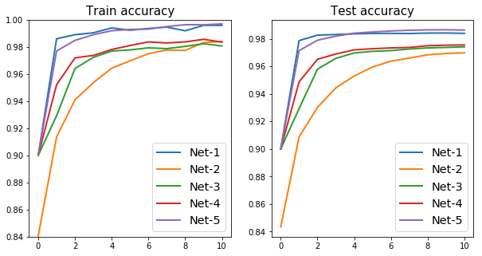

```python
ax1.plot(train_accuracy5, linewidth = 2, label = "Net-5")
ax1.legend(loc = 'lower right', fontsize = 'x-large')
ax2.plot(test_accuracy5, linewidth = 2, label = "Net-5")
ax2.legend(loc = 'lower right', fontsize = 'x-large')
fig
```

| **Network Architecture** | **Links** | **Weights** | **Test accuracy** |
| --- | --- | --- | --- |
| Net-1: Single layer network | 2570 | 2570 | 0.983906 |
| Net-2: Two layer network | 3214 | 3214 | 0.969806 |
| Net-3: Locally connected | 1226 | 1226 | 0.974141 |
| Net-4: Constrained network1 | 2266 | 1132 | 0.975486 |
| Net-5: Constrained network2 | 5194 | 1060 | 0.986298 |

I notice neural network always vouch performance. Multinomial logistics can also provide enough performance and when we use one hidden layer, do not use relu activation function. That can be produced error.